# Script 4

Boris Mericskay et Florent Demoraes

27/07/2021

LES DONNÉES DVF À UNE ÉCHELLE LOCALE : LES EXEMPLES DE LA MÉTROPOLE RÉGIONALE ET DE LA COMMUNE DE RENNES

Ce script présente toutes les étapes de manipulation de la dimension spatiale des données DVF et propose plusieurs formes de représentation cartographique de ces données à une échelle métropolitaine (Rennes Métropole).

```r
library(tidyverse)
library(sf)
```

```r
library(cartography)
```

### Définition de l’environnement de travail

### Importer le jeux de données (si nécessaire)

```r
MutationsBZH <- st_read("Exports/MutationsBZH.gpkg")
```

## 2-Exploration des prix et des volumes à l’échelon des IRIS

### Importer la couche des IRIS (IGN)

```r
IRISRM <- st_read(dsn = "DATA/IRISRM.shp", stringsAsFactors = FALSE)
```

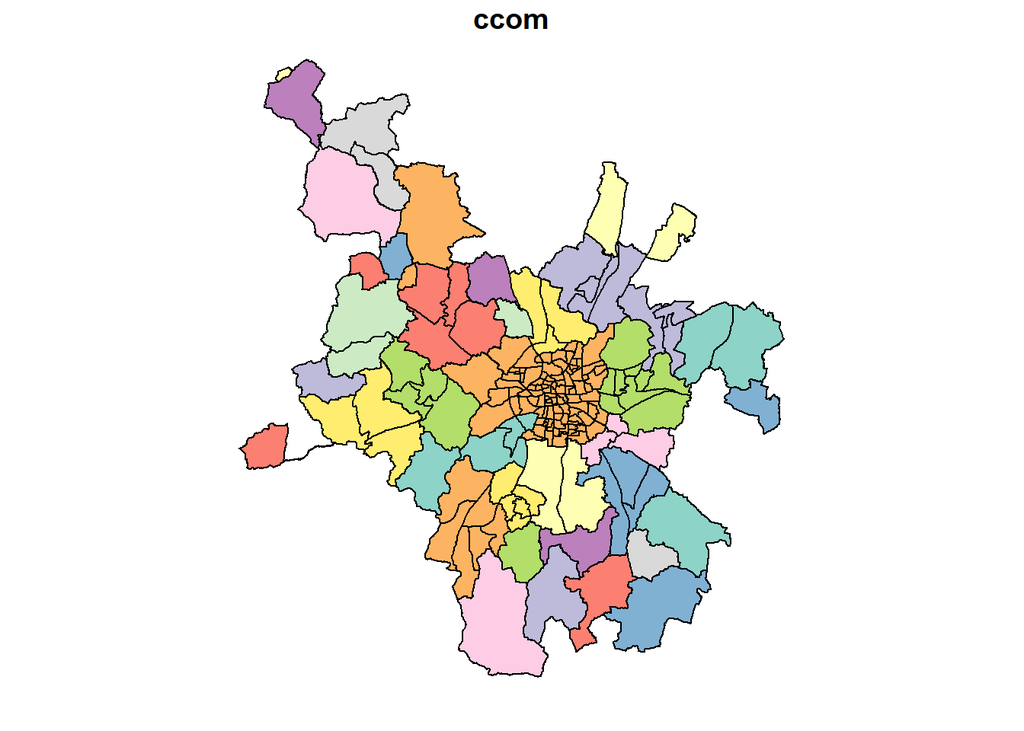

```r
plot(IRISRM["ccom"])
```

### Calculer et cartographier le prix moyen au m² par IRIS

```r
# Réimporter si nécessaire la couche des communes de Bretagne (Admin Express IGN) et la reprojeter
Communes <- st_read(dsn = "DATA/Communes.shp", stringsAsFactors = FALSE)
```

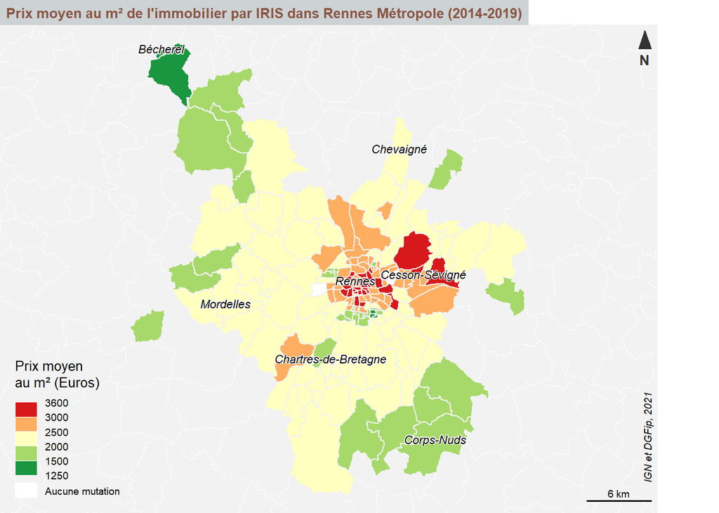

```r
# Calcul du prix moyen au m² par IRIS
IRISDVF <- IRISRM %>% st_join(MutationsRM) %>% group_by(code_iris) %>% summarise(Prixm2 = mean(prixm2))

# Sélection des communes dont le nom sera affiché sur la carte
liste_noms_RM <- c("Rennes", "Cesson-Sévigné", "Chartres-de-Bretagne", "Bécherel", "Mordelles", "Corps-Nuds", "Chevaigné")
Selection_Communes_RM <- Communes[which(Communes$NOM_COM %in% liste_noms_RM),]

# Parametrage des marges de la fenetre pour maximiser l'emprise de la carte
par(mar = c(0, 0, 1.2, 3))

# Affichage des communes de RM et alentours en arrière-plan et centrage de la carte sur Rennes Métropole
plot(st_geometry(Communes), lwd = 0.1, col = "grey95", border = "white", bg = "#B5D0D0", xlim = c(st_bbox(IRISRM)[1], st_bbox(IRISRM)[3]), ylim = c(st_bbox(IRISRM)[2], st_bbox(IRISRM)[4]))

choroLayer(
  x = IRISDVF,
  var = "Prixm2",
  breaks = c(1250, 1500, 2000, 2500, 3000, 3600),
  col = c("#1a9641", "#a6d96a", "#ffffbf", "#fdae61", "#d7191c"),
  add = TRUE,
  border = "grey95",
  legend.nodata = "Aucune mutation",
  legend.border = "white",
  legend.title.txt = "Prix moyen \nau m² (Euros)")

layoutLayer(title = "Prix moyen au m² de l'immobilier par IRIS dans Rennes Métropole (2014-2019)", source = "         IGN et DGFip, 2021",
            north = TRUE, horiz = FALSE, tabtitle = TRUE,
            frame = FALSE, col = "#cdd2d4", coltitle = "#8A5543")

# Ajouter les étiquettes des communes selectionnées plus haut
labelLayer(Selection_Communes_RM, txt = "NOM_COM", halo = TRUE, bg = "white", r = 0.05, cex = 0.7, pos = 3, font = 3, offset = 0, overlap = TRUE)
```

### Calculer et cartographier le nombre de mutations par IRIS

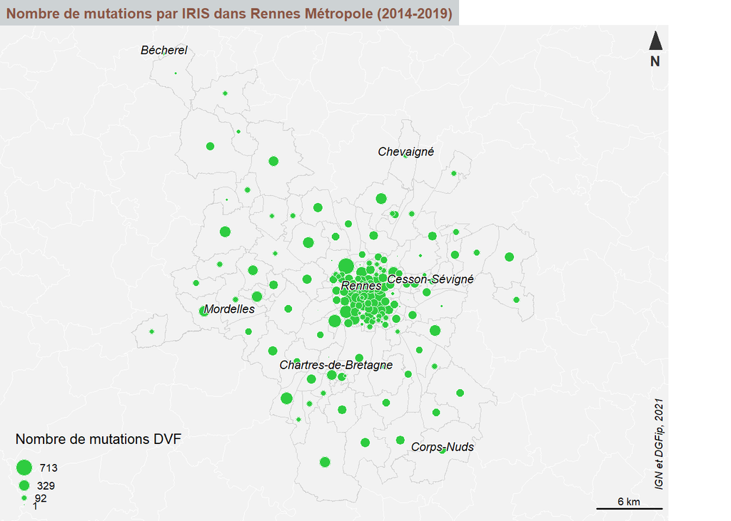

```r
# Calcul du nombre de mutations par IRIS
IRISDVF <- IRISDVF %>% mutate(Nbmutations = lengths(st_intersects(IRISDVF, MutationsRM)))
IRISDVF <- IRISDVF %>% na.omit() # pour supprimer les valeurs manquantes

# Parametrage des marges de la fenetre pour maximiser l'emprise de la carte
par(mar = c(0, 0, 1.2, 3))

# Affichage des communes de RM et alentours en arrière-plan et centrage de la carte sur Rennes Métropole
plot(st_geometry(Communes), lwd = 0.1, col = "grey95", border = "white", bg = "#B5D0D0", xlim = c(st_bbox(IRISRM)[1], st_bbox(IRISRM)[3]), ylim = c(st_bbox(IRISRM)[2], st_bbox(IRISRM)[4]))

# Affichage des IRIS
plot(st_geometry(IRISRM), # appel du jeu de données
     border = "grey80", # couleur de la bordure des IRIS
     add = TRUE,
     lwd = 0.05)

# Affichage des symboles proportionnels (nombre de mutations)
propSymbolsLayer(x = IRISDVF, # appel du jeu de données
                 var = "Nbmutations", # appel de la variable à cartographier
                 col = "#2ECC40", # couleur cercles
                 border = "white",  # couleur bordure cercle
                 lwd = 0.01,
                 inches = 0.08, # Taille des cercles
                 add = TRUE,
                 legend.pos = "n",
                 )

layoutLayer(title = "Nombre de mutations par IRIS dans Rennes Métropole (2014-2019)", source = "         IGN et DGFip, 2021", north = TRUE, horiz = FALSE, tabtitle = TRUE, frame = FALSE, col = "#cdd2d4", coltitle = "#8A5543")

legendCirclesSymbols(
  pos = "bottomleft",
  title.txt = "Nombre de mutations DVF",
  title.cex = 0.8,
  cex = 1,
  border = "white",
  lwd = 0.01,
  values.cex = 0.6,
  var = c(min(IRISDVF$Nbmutations), max(IRISDVF$Nbmutations)),
  inches = 0.08,
  col = "#2ECC40",
  frame = FALSE,
  values.rnd = 0,
  style = "e"
)

# Ajouter les étiquettes des communes selectionnées plus haut
labelLayer(Selection_Communes_RM, txt = "NOM_COM", halo = TRUE, bg = "white", r = 0.05, cex = 0.7, pos = 3, font = 3, offset = 0, overlap = TRUE)
```

## 4-Lissage spatial (échelle métropolitaine)

### Chargement des packages nécessaires

```r
library(sp) # pour importer des objets ayant une composante spatiale
library(rgdal) # pour manipuler des objets ayant une composante spatiale
library(rgeos) # pour calculer des centroides
library(spdep) # pour calculer l'auto-corrélation spatiale
library(geoR) # pour calculer le semi-variogramme empirique
library(spatstat) # pour produire des surfaces lissées
library(maptools) # pour le traitement cartographique
library(raster) # pour le traitement de données matricielles
```

### Lissage spatial des prix de l’immobilier au m² calculés à partir des valeurs agrégées par IRIS

#### Calcul des distances au plus proche voisin et de l’auto-corrélation spatiale des prix au m²

```r
# pour convertir la couche des IRIS au format spatial object (format requis par le package geoR)
IRISDVF.sp <- as(IRISDVF, "Spatial")

# pour calculer les centroides des IRIS (indispensable pour le calcul sur les plus proches voisins)
IRISDVF.Centroids <- gCentroid(IRISDVF.sp,byid=TRUE)

# pour récupérer les données initiales des IRIS sur les centroides
IRISDVF.Centroids <- SpatialPointsDataFrame(IRISDVF.Centroids, IRISDVF.sp@data)

# Calcul sur les plus proches voisins
listPPV <- knearneigh(IRISDVF.Centroids@coords, k = 1) # pour connaître le plus proche voisin de chaque commune
PPV <- knn2nb(listPPV, row.names = IRISDVF.Centroids$code_iris) # pour convertir l'objet knn en objet nb
distPPV <- nbdists(PPV, IRISDVF.Centroids@coords) # pour connaître la distance entre plus proches voisins
print(as.data.frame(t(as.matrix(summary(unlist(distPPV))))))
```

```
##       Min.  1st Qu.   Median     Mean  3rd Qu.     Max.
## 1 202.9839 403.8551 687.9196 1274.407 2035.178 5161.367
```

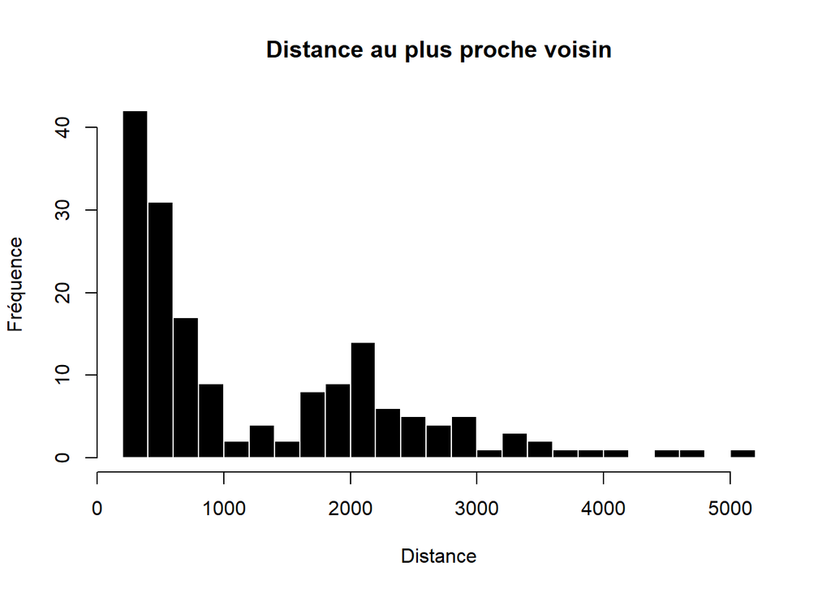

```r
hist(unlist(distPPV), breaks = 20,
     main = "Distance au plus proche voisin",
     col = "black", border = "white", xlab = "Distance", ylab = "Fréquence")
```

```r
# pour convertir les IRIS en objet nb
IRIS.nb <- poly2nb(pl = IRISDVF,
                 row.names = IRISDVF$code_iris,
                 snap = 50,
                 queen = TRUE)

#calcul du test de Moran
moran.test(IRISDVF$Prixm2, listw = nb2listw(IRIS.nb))
```

```
##
##  Moran I test under randomisation
##
## data:  IRISDVF$Prixm2
## weights: nb2listw(IRIS.nb)
##
## Moran I statistic standard deviate = 14.586, p-value < 2.2e-16
## alternative hypothesis: greater
## sample estimates:
## Moran I statistic       Expectation          Variance
##       0.686719218      -0.005917160       0.002254837
```

#### Carte lissée des prix de l’immobilier au m² calculés à partir des valeurs agrégées par IRIS sur l’ensemble de Rennes Métropole

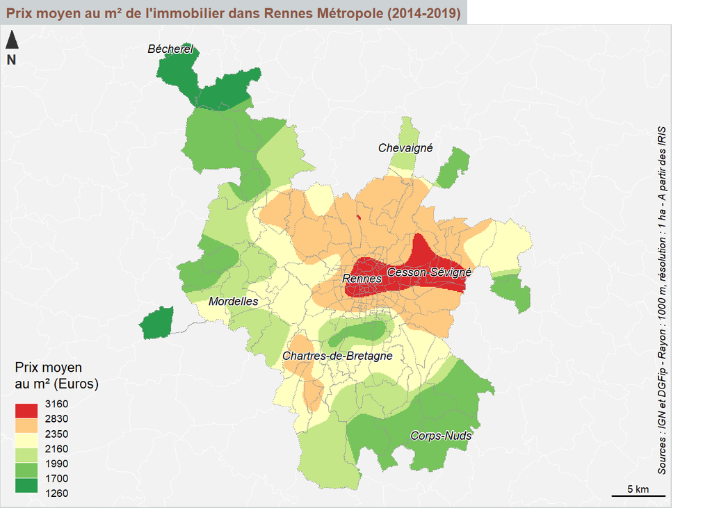

```r
# pour définir le contour de Rennes Métropole comme emprise pour le lissage (sinon le lissage est calculé sur une fenêtre rectangulaire)
EmpriseRM <- as.owin(as(IRISRM, "Spatial"))

# pour récupérer les coordonnées du centroïde des IRIS
pts <- st_coordinates(st_point_on_surface(st_geometry(IRISDVF)))

# pour créer un objet ppp (format spatstat) et y intégrer dedans l'emprise et les valeurs à lisser (prix au m²)
IRISDVF.ppp <- ppp(pts[,1], pts[,2], window = EmpriseRM, marks = IRISDVF$Prixm2)

# pour calculer la surface lissée (rayon lissage : 1 km et resolution spatiale de l'image : 1 ha)
cartelissee <- Smooth(IRISDVF.ppp, sigma = 1000, weights = IRISDVF.ppp$marks, eps=100)

# Conversion de la surface lissée au format raster
cartelissee.raster <- raster(cartelissee, crs = st_crs(IRISDVF)[[2]])

# Parametrage des marges de la fenetre pour maximiser l'emprise de la carte
par(mar = c(0, 0, 1.2, 2))

# pour afficher la surface lissée et définir l'habillage
# Calcul des seuils
bks <- unique(getBreaks(values(cartelissee.raster), method = "q6"))

# Création d'une palette de couleurs (double gradation harmonique)
cols <- c("#2a9c4e", "#77c35c", "#c4e687", "#ffffc0", "#fec981", "#dc292c")

# Affichage des communes de RM et alentours en arrière-plan et centrage de la carte sur Rennes Métropole
plot(st_geometry(Communes), lwd = 0.1, col = "grey95", border = "white", bg = "#B5D0D0", xlim = c(st_bbox(IRISRM)[1], st_bbox(IRISRM)[3]), ylim = c(st_bbox(IRISRM)[2], st_bbox(IRISRM)[4]))

# Affichage de la carte lissée et du contour des IRIS
plot(cartelissee.raster, breaks = bks, col=cols, add = T, legend=F)
plot(IRISDVF$geometry, border = "grey60", lwd = 0.05, lty=3, add = T)

legendChoro(
  pos = "bottomleft",
  title.txt = "Prix moyen \nau m² (Euros)",
  breaks = bks,
  nodata = FALSE,
  values.rnd = -1,
  border = "white",
  col = cols
)

layoutLayer(title = "Prix moyen au m² de l'immobilier dans Rennes Métropole (2014-2019)",
            author = "          Sources : IGN et DGFip - Rayon : 1000 m, résolution : 1 ha - A partir des IRIS",
            scale = 5, frame = TRUE, col = "#cdd2d4", coltitle = "#8A5543",
            north(pos = "topleft"), tabtitle=TRUE, horiz = FALSE)

# Ajouter les etiquettes des communes selectionnees plus haut
labelLayer(Selection_Communes_RM, txt = "NOM_COM", halo = TRUE, bg = "white", r = 0.05, cex = 0.7, pos = 3, font = 3, offset = 0)
```

### Lissage spatial du prix de l’immobilier au m² calculés à partir des valeurs agrégées par section cadastrale

#### Calcul des distances au plus proche voisin et de l’auto-corrélation spatiale des prix au m²

```r
# pour convertir la couche des sections au format spatial object (format requis par le package geoR)
SectionsDVF.sp <- as(SectionsDVF, "Spatial")

# pour calculer les centroides des sections (indispensable pour le calcul sur les plus proches voisins)
SectionsDVF.Centroids <- gCentroid(SectionsDVF.sp,byid=TRUE)

# pour récupérer les données initiales des sections sur les centroides
SectionsDVF.Centroids <- SpatialPointsDataFrame(SectionsDVF.Centroids, SectionsDVF.sp@data)

# Calcul sur les plus proches voisins
listPPV <- knearneigh(SectionsDVF.Centroids@coords, k = 1) # pour connaître le plus proche voisin de chaque commune
PPV <- knn2nb(listPPV, row.names = SectionsDVF.Centroids$codesection) # pour convertir l'objet knn en objet nb
distPPV <- nbdists(PPV, SectionsDVF.Centroids@coords) # pour connaître la distance entre plus proches voisins
print(as.data.frame(t(as.matrix(summary(unlist(distPPV))))))
```

```
##       Min.  1st Qu.   Median     Mean  3rd Qu.    Max.
## 1 70.90299 444.2811 541.0992 652.7353 802.2466 2284.75
```

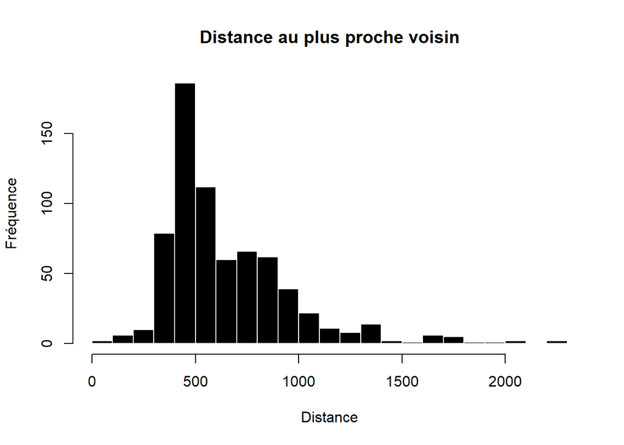

```r
hist(unlist(distPPV), breaks = 20,
     main = "Distance au plus proche voisin",
     col = "black", border = "white", xlab = "Distance", ylab = "Fréquence")
```

```r
# pour convertir les sections en objet nb
Section.nb <- poly2nb(pl = SectionsDVF,
                 row.names = SectionsDVF$codesection,
                 snap = 50,
                 queen = TRUE)

#calcul du test de Moran
moran.test(SectionsDVF$Prixm2, listw = nb2listw(Section.nb))
```

```
##
##  Moran I test under randomisation
##
## data:  SectionsDVF$Prixm2
## weights: nb2listw(Section.nb)
##
## Moran I statistic standard deviate = 19.432, p-value < 2.2e-16
## alternative hypothesis: greater
## sample estimates:
## Moran I statistic       Expectation          Variance
##      0.4734741475     -0.0014367816      0.0005972924
```

#### Carte lissée des prix de l’immobilier au m² calculés à partir des valeurs agrégées par section cadastrale sur l’ensemble de Rennes Métropole

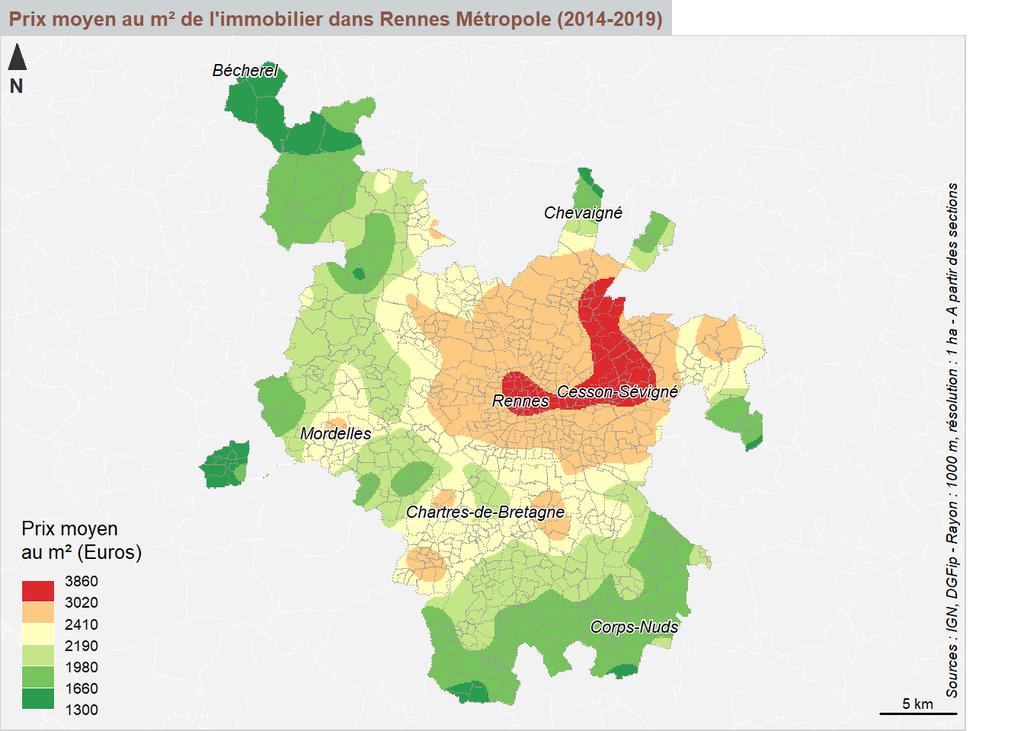

```r
# pour définir le contour de Rennes Métropole comme emprise pour le lissage (sinon le lissage est calculé sur une fenêtre rectangulaire)
EmpriseRM <- as.owin(as(IRISRM, "Spatial"))

# pour récupérer les coordonnées du centroïde des sections
pts <- st_coordinates(st_point_on_surface(st_geometry(SectionsDVF)))

# pour créer un objet ppp (format spatstat) et y intégrer dedans l'emprise et les valeurs à lisser (prix au m²)
Sections.ppp <- ppp(pts[,1], pts[,2], window = EmpriseRM, marks = SectionsDVF$Prixm2)

# pour calculer la surface lissée (rayon lissage : 1 km et resolution spatiale de l'image : 1 ha)
cartelissee <- Smooth(Sections.ppp, sigma = 1000, weights = Sections.ppp$marks, eps=100)

# Conversion de la surface lissée au format raster
cartelissee.raster <- raster(cartelissee, crs = st_crs(SectionsDVF)[[2]])

# Parametrage des marges de la fenetre pour maximiser l'emprise de la carte
par(mar = c(0, 0, 1.2, 2))

# pour afficher la surface lissée et définir l'habillage
# Calcul des seuils
bks <- unique(getBreaks(values(cartelissee.raster), method = "q6"))

# Création d'une palette de couleurs (double gradation harmonique)
cols <- c("#2a9c4e", "#77c35c", "#c4e687", "#ffffc0", "#fec981", "#dc292c")

# Affichage des communes de RM et alentours en arrière-plan et centrage de la carte sur Rennes Métropole
plot(st_geometry(Communes), lwd = 0.1, col = "grey95", border = "white", bg = "#B5D0D0", xlim = c(st_bbox(SectionsDVF)[1], st_bbox(SectionsDVF)[3]), ylim = c(st_bbox(SectionsDVF)[2], st_bbox(SectionsDVF)[4]))

# Affichage de la carte lissée et du contour des sections
plot(cartelissee.raster, breaks = bks, col=cols, add = T, legend=F)
plot(SectionsDVF$geometry, border = "grey60", lwd = 0.05, lty=3, add = T)

legendChoro(
  pos = "bottomleft",
  title.txt = "Prix moyen \nau m² (Euros)",
  breaks = bks,
  nodata = FALSE,
  values.rnd = -1,
  border = "white",
  col = cols
)

layoutLayer(title = "Prix moyen au m² de l'immobilier dans Rennes Métropole (2014-2019)",
            author = "      Sources : IGN, DGFip - Rayon : 1000 m, résolution : 1 ha - A partir des sections",
            scale = 5, frame = TRUE, col = "#cdd2d4", coltitle = "#8A5543",
            north(pos = "topleft"), tabtitle=TRUE, horiz = FALSE)

# Ajouter les étiquettes des communes sélectionnées plus haut
labelLayer(Selection_Communes_RM, txt = "NOM_COM", halo = TRUE, bg = "white", r = 0.05, cex = 0.7, pos = 3, font = 3, offset = 0)
```

### Lissage spatial des prix de l’immobilier au m² calculés directement à partir des mutations immobilières sur l’ensemble de Rennes Métropole

#### Calcul de la distance au plus proche voisin et de l’auto-corrélation spatiale des prix au m²

```r
# pour convertir les mutations en objet spatial (format requis par le package geoR)
MutationsRM.sp <- as(MutationsRM, "Spatial")

# Calcul sur les plus proches voisins
listPPV <- knearneigh(MutationsRM.sp@coords, k = 1) # pour connaître le plus proche voisin de chaque mutation
PPV <- knn2nb(listPPV, row.names = MutationsRM.sp$id) # pour convertir l'objet knn en objet nb
distPPV <- nbdists(PPV, MutationsRM.sp@coords) # pour connaître la distance entre plus proches voisins
print(as.data.frame(t(as.matrix(summary(unlist(distPPV))))))
```

```
##   Min. 1st Qu. Median     Mean  3rd Qu.     Max.
## 1    0       0      0 20.50225 20.81376 1780.256
```

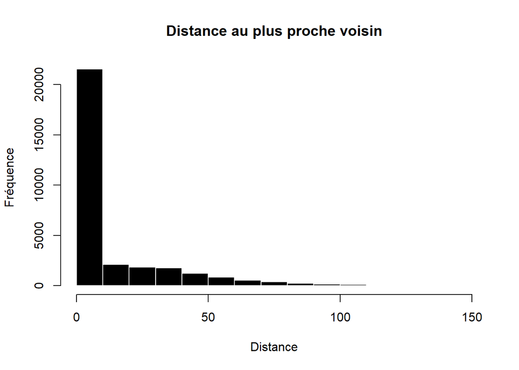

```r
hist(unlist(distPPV), nclass = 200,
     main = "Distance au plus proche voisin",
     col = "black", border = "white", xlab = "Distance", ylab = "Fréquence", xlim = c(0,150))
```

```r
#calcul du test de Moran
moran.test(MutationsRM.sp$prixm2, listw = nb2listw(PPV))
```

```
##
##  Moran I test under randomisation
##
## data:  MutationsRM.sp$prixm2
## weights: nb2listw(PPV)
##
## Moran I statistic standard deviate = 80.87, p-value < 2.2e-16
## alternative hypothesis: greater
## sample estimates:
## Moran I statistic       Expectation          Variance
##      5.371041e-01     -3.152486e-05      4.411613e-05
```

#### Carte lissée des prix de l’immobilier au m² calculés directement à partir des mutations immobilières sur l’ensemble de Rennes Métropole

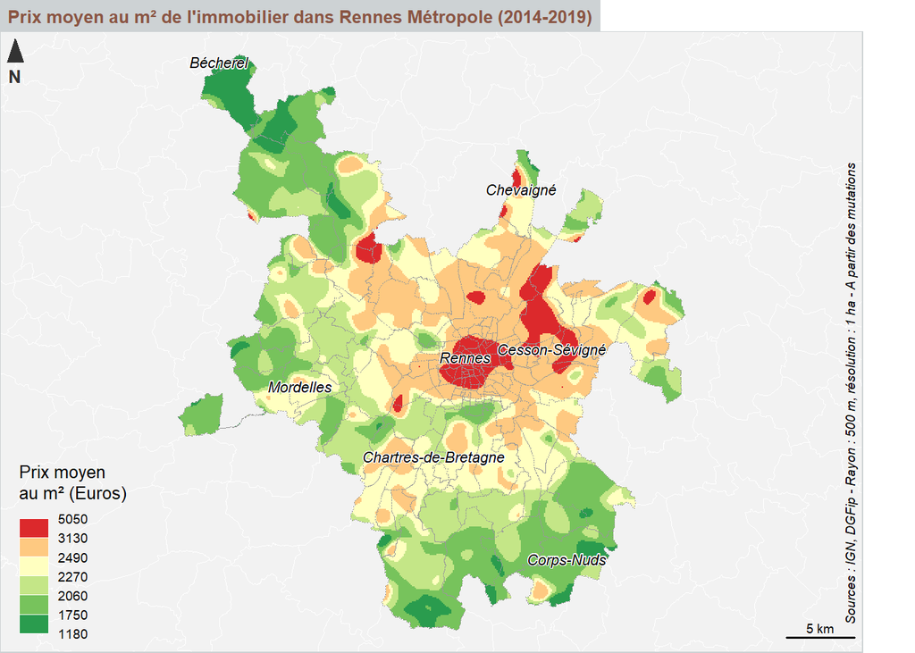

```r
# Si nécessaire,  convertir les mutations en objet spatial (format requis par le package geoR)
MutationsBZHsp <- as(MutationsBZH, "Spatial")

# pour définir comme emprise pour le lissage, l'étendue de Rennes métropole avec une zone tampon de 0,5 km autour afin d'englober les mutations limitrophes et réduire l'effet de bord
EmpriseRM.ZT <- as.owin(as(st_union(st_buffer(IRISRM, 500)), "Spatial"))

# pour créer un objet ppp (format spatstat) et y intégrer dedans l'emprise et les valeurs à lisser (prix moyen au m²)
# NB : on considère dans un premier temps les mutations sur l'ensemble de la Bretagne, et on ne retient que celles qui sont incluses dans l'emprise créée à l'étape précédente
MutationsBZHsp.ppp <- ppp(MutationsBZHsp@coords[,1], MutationsBZHsp@coords[,2], window = EmpriseRM.ZT, marks = MutationsBZHsp$prixm2)

# pour calculer la surface lissée (rayon lissage : 0,5 km et résolution spatiale de l'image : 1 ha) --> calcul long
cartelissee <- Smooth(MutationsBZHsp.ppp, sigma = 500, weights = MutationsBZHsp.ppp$marks, eps=100)

# Conversion de la surface lissée au format raster
cartelissee.raster <- raster(cartelissee, crs = st_crs(MutationsRM)[[2]])

# découpage de la surface lissée sur l'emprise Rennes Métropole
cartelissee.raster <- mask(cartelissee.raster, IRISRM)

# Parametrage des marges de la fenêtre pour maximiser l'emprise de la carte
par(mar = c(0, 0, 1.2, 2))

# pour afficher la surface lissée et définir l'habillage de la carte
# Calcul des seuils
bks <- unique(getBreaks(values(cartelissee.raster), method = "q6"))

# Création d'une palette de couleurs (double gradation harmonique)
cols <- c("#2a9c4e", "#77c35c", "#c4e687", "#ffffc0", "#fec981", "#dc292c")

# Affichage des communes de RM et alentours en arrière-plan et centrage de la carte sur Rennes Métropole
plot(st_geometry(Communes), lwd = 0.1, col = "grey95", border = "white", bg = "#B5D0D0", xlim = c(st_bbox(IRISRM)[1], st_bbox(IRISRM)[3]), ylim = c(st_bbox(IRISRM)[2], st_bbox(IRISRM)[4]))

# Affichage de la carte lissée et du contour des IRIS
plot(cartelissee.raster, breaks = bks, col=cols, add = T, legend=F)
plot(IRISRM$geometry, border = "grey60", lwd = 0.05, lty=3, add = T)

legendChoro(
  pos = "bottomleft",
  title.txt = "Prix moyen \nau m² (Euros)",
  breaks = bks,
  nodata = FALSE,
  values.rnd = -1,
  border = "white",
  col = cols
)

layoutLayer(title = "Prix moyen au m² de l'immobilier dans Rennes Métropole (2014-2019)",
            author = "      Sources : IGN, DGFip - Rayon : 500 m, résolution : 1 ha - A partir des mutations",
            scale = 5, frame = TRUE, col = "#cdd2d4", coltitle = "#8A5543",
            north(pos = "topleft"), tabtitle=TRUE, horiz = FALSE)

# Ajouter les étiquettes des communes sélectionnées plus haut
labelLayer(Selection_Communes_RM, txt = "NOM_COM", halo = TRUE, bg = "white", r = 0.05, cex = 0.7, pos = 3, font = 3, offset = 0)
```

## 5-Elaboration d’une typologie à partir d’indicateurs immobiliers et cartographie des sous-marchés associés (échelle métropolitaine)

### Chargement du package nécessaire

```r
library(cluster)
```

### Transfert d’attributs des IRIS vers les mutations (jointure spatiale)

```r
MutationsIRIS <- MutationsRM %>% st_join(IRISRM)
```

### Tableau récapitulatif des variables par IRIS à soumettre à la CAH

```r
IRISDVFClassif1 <- MutationsIRIS %>% group_by(code_iris) %>%
  summarise(Nbtransactions = n(),
            Prixmoyen = mean(prix),
            Prixm2moyen = mean(prixm2),
            Surfacemoyenne = mean(surface),
            PropMaison = length(type[type=="Maison"])/Nbtransactions*100,
            PropAppart = length(type[type=="Appartement"])/Nbtransactions*100)

# pour créer un nouveau tableau sans composante géométrique avec une sélection de colonnes
IRISDVFClassif1$geom <- NULL
IRISDVFClassif <- data.frame(IRISDVFClassif1[, c("Nbtransactions", "Prixmoyen", "Prixm2moyen", "Surfacemoyenne", "PropMaison", "PropAppart")])
```

### Centrage et réduction des variables

```r
IRISDVFClassifscale <- scale(IRISDVFClassif)
```

### Mise en oeuvre de la CAH

```r
CAHIRIS <- agnes(IRISDVFClassifscale,
                     metric = "euclidean",
                     method = "ward")
```

### Graphiques des gains d’inertie inter-classe

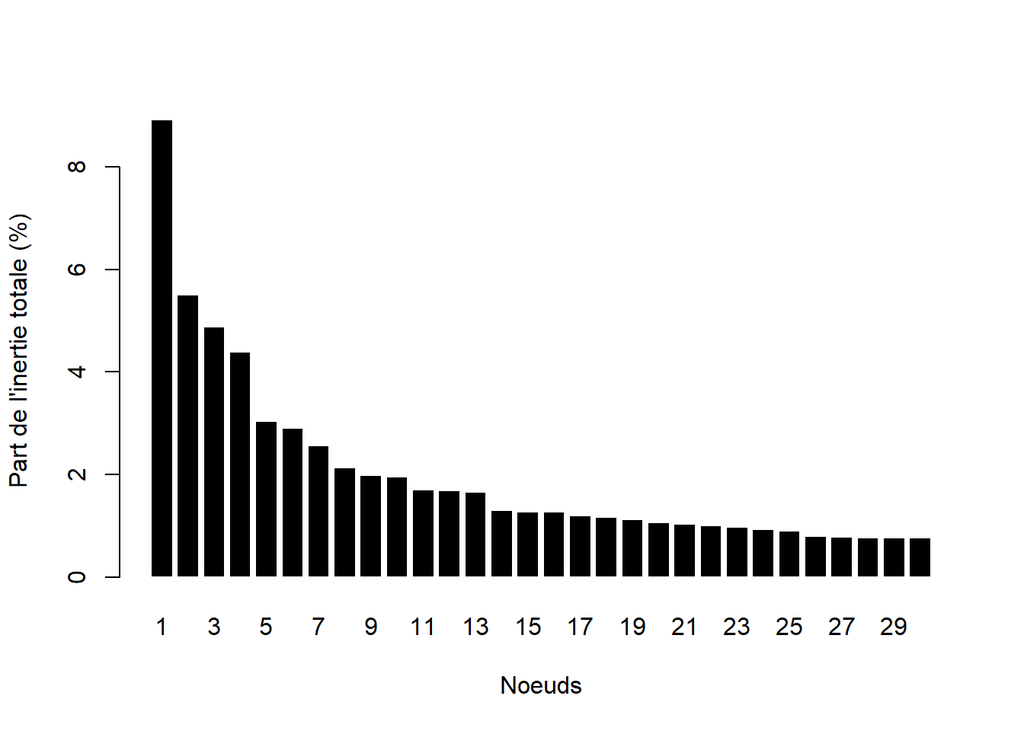

```r
sortedHeight<- sort(CAHIRIS$height,decreasing= TRUE)
relHeight<-sortedHeight/ sum(sortedHeight)*100
cumHeight<- cumsum(relHeight)

barplot(relHeight[1:30],names.arg=seq(1, 30, 1),col= "black",border= "white",xlab= "Noeuds",ylab= "Part de l'inertie totale (%)")
```

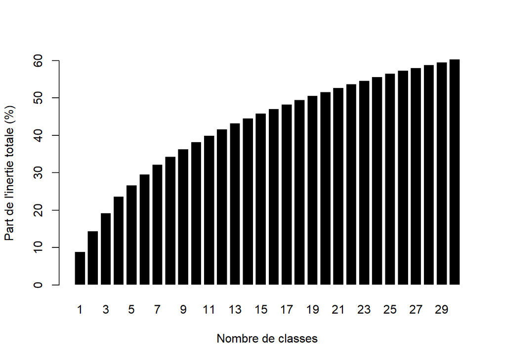

```r
barplot(cumHeight[1:30],names.arg=seq(1, 30, 1),col= "black",border= "white",xlab= "Nombre de classes",ylab= "Part de l'inertie totale (%)")
```

### Arbre de classification hiérarchique (dendrogramme)

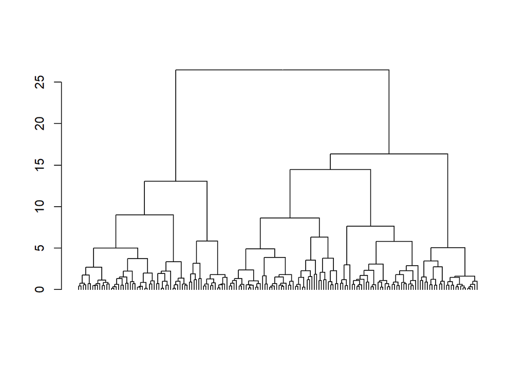

```r
dendroCSP <- as.dendrogram(CAHIRIS)
plot(dendroCSP, leaflab = "none")
```

### Partition (en n classes)

```r
clusIRIS <- cutree(CAHIRIS, k = 5)
IRISCluster <- as.data.frame(IRISDVFClassif1)
IRISCluster$CLUSIMMO <- factor(clusIRIS,
                                   levels = 1:5,
                                   labels = paste("Classe", 1:5))
```

### Tableau récapitulatif des groupes

```r
RecapCAHIRIS <- IRISCluster %>% group_by(CLUSIMMO) %>% summarise(NB= n(), NbTransac = mean(Nbtransactions), Prixmoyen = mean(Prixmoyen), Prixm2 = mean(Prixm2moyen), Surface=mean(Surfacemoyenne), PropMaison = mean(PropMaison), PropAppart= mean(PropAppart))

print(RecapCAHIRIS)
```

```
## # A tibble: 5 x 8
##   CLUSIMMO    NB NbTransac Prixmoyen Prixm2 Surface PropMaison PropAppart
##   <fct>    <int>     <dbl>     <dbl>  <dbl>   <dbl>      <dbl>      <dbl>
## 1 Classe 1    47     199.    190964.  2068.    94.5      70.9       29.1
## 2 Classe 2    17      82.9   286322.  2393.   121.       91.9        8.12
## 3 Classe 3    47     160.    221025.  2817.    78.2      39.2       60.8
## 4 Classe 4    34     302.    163057.  2882.    57.6       7.98      92.0
## 5 Classe 5    25     125.    126790.  1782.    71.5       8.32      91.7
```

### Graphique des écarts à la moyenne

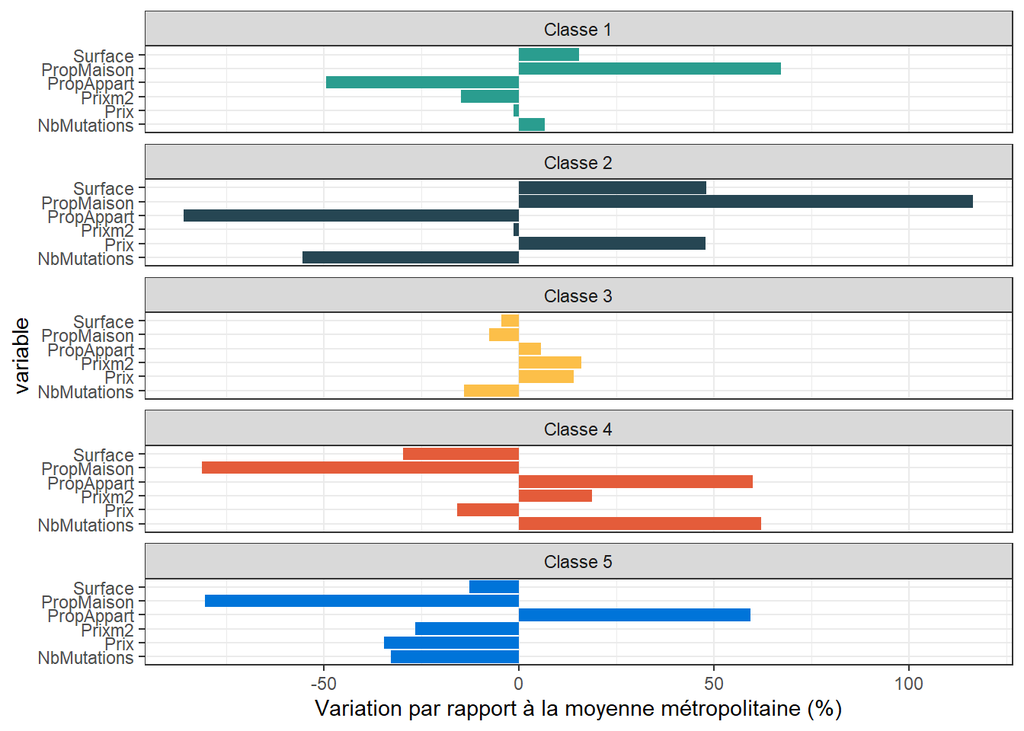

```r
SyntheseCAHIRIS <- RecapCAHIRIS %>% mutate(
  nbtransacmoy = mean(IRISDVFClassif$Nbtransactions),
  surfacemoy = mean(IRISDVFClassif$Surfacemoyenne),
  prixmoy = mean(IRISDVFClassif$Prixmoyen),
  prixm2moyen = mean(IRISDVFClassif$Prixm2moyen),
  propmaisonmoyen = mean(IRISDVFClassif$PropMaison),
  propappartmoyen = mean(IRISDVFClassif$PropAppart),
  NbMutations=(NbTransac- nbtransacmoy)/nbtransacmoy*100,
  Prix=(Prixmoyen- prixmoy)/prixmoy*100,
  Prixm2=(Prixm2- prixm2moyen)/prixm2moyen*100,
  Surface=(Surface- surfacemoy)/surfacemoy*100,
  PropMaison=(PropMaison- propmaisonmoyen)/propmaisonmoyen*100,
  PropAppart=(PropAppart- propappartmoyen)/propappartmoyen*100
)

# pour créer un nouveau tableau avec une sélection de colonnes à faire apparaître sur le graphique
SyntheseCAHIRIS <- data.frame(SyntheseCAHIRIS[, c("CLUSIMMO", "NbMutations", "Surface", "Prix", "Prixm2", "PropMaison", "PropAppart")])

gather <- SyntheseCAHIRIS %>% gather(key=variable, value= "value", NbMutations:PropAppart)

ggplot(gather, aes(x=variable, y=value, fill=CLUSIMMO)) +
  geom_bar(stat = "identity") +
  coord_flip() +
  scale_fill_manual(values=c("#2A9D8F","#264653","#fcbf49","#e45c3a","#0074D9")) +
  ylab("Variation par rapport à la moyenne métropolitaine (%)") +
  theme_bw() +
  theme(legend.position = "none") +
  facet_wrap(~CLUSIMMO, ncol = 1)
```

### Carte de la typologie montrant les sous-marchés immobiliers métropolitains

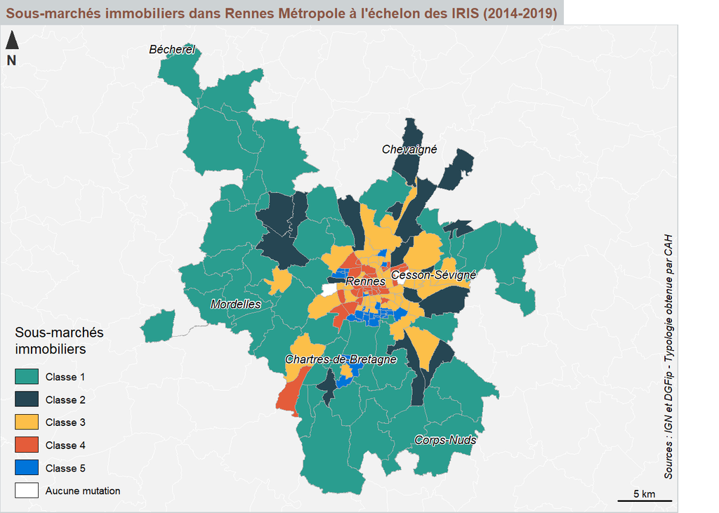

```r
# pour joindre le résultat de la typologie dans la couche des IRIS
IRISDVFCAH <- left_join(IRISRM, IRISCluster, by= "code_iris")

# Parametrage des marges de la fenêtre pour maximiser l'emprise de la carte
par(mar = c(0, 0, 1.2, 2))

# pour afficher la surface lissée et définir l'habillage de la carte
# Calcul des seuils
bks <- unique(getBreaks(values(cartelissee.raster), method = "q6"))

# Création d'une palette de couleurs (double gradation harmonique)
cols <- c("#2a9c4e", "#77c35c", "#c4e687", "#ffffc0", "#fec981", "#dc292c")

# Affichage des communes de RM et alentours en arrière-plan et centrage de la carte sur Rennes Métropole
plot(st_geometry(Communes), lwd = 0.1, col = "grey95", border = "white", bg = "#B5D0D0", xlim = c(st_bbox(IRISRM)[1], st_bbox(IRISRM)[3]), ylim = c(st_bbox(IRISRM)[2], st_bbox(IRISRM)[4]))

# Affichage de la typologie et du contour des IRIS
typoLayer(
  x = IRISDVFCAH,
  var="CLUSIMMO",
  col = c("#2A9D8F","#264653","#fcbf49","#e45c3a","#0074D9"),
  lwd = 0.05,
  border = "grey70",
  legend.values.order = c("Classe 1",
                          "Classe 2",
                          "Classe 3",
                          "Classe 4",
                          "Classe 5"),
  legend.pos = "bottomleft",
  legend.title.txt = "Sous-marchés \nimmobiliers",
  legend.nodata = "Aucune mutation",
  add = TRUE)

layoutLayer(title = "Sous-marchés immobiliers dans Rennes Métropole à l'échelon des IRIS (2014-2019)",
            author = "          Sources : IGN et DGFip - Typologie obtenue par CAH",
            scale = 5, frame = TRUE, col = "#cdd2d4", coltitle = "#8A5543",
            north(pos = "topleft"), tabtitle=TRUE, horiz = FALSE)

# Ajouter les étiquettes des communes sélectionnées plus haut
labelLayer(Selection_Communes_RM, txt = "NOM_COM", halo = TRUE, bg = "white", r = 0.05, cex = 0.7, pos = 3, font = 3, offset = 0)
```

### Export des IRIS contenant la typologie au format geopackage (pour une utilisation dans un SIG par exemple)

## 6-Lissage spatial des prix au m² des appartements entre 2014 et 2019 : zoom sur la commune de Rennes

### Préparation du jeu de données

```r
# pour ne garder que la commmune de Rennes
CommuneRennes <- Communes %>% filter(NOM_COM == "Rennes")

# pour ne garder que les mutations correspondant à des appartements dans Rennes Métropole (dans un premier temps)
MutationsApptRM <- MutationsRM %>% filter(type == "Appartement")

# pour créer une liste d'années, dans l'ordre
MutationsApptRM<-MutationsApptRM[order(MutationsApptRM$annee, decreasing = FALSE), ]
ListAnnees <- unique(MutationsApptRM$annee)
```

### Série de cartes lissées montrant l’évolution des prix au m² des appartements calculés directement à partir des mutations, à Rennes entre 2014 et 2019